# Space-Time Prediction of Bike Share Demand - Indego in Philadelphia, PA

Zizhao He

8/7/2020

## 1. Executive Summary

A bike-share program is a service in which bicycles are made available for shared use to individuals on a short term basis for a price or free. It allows people to borrow a bike from a “dock” and return it at another dock belonging to the same system. The central concept of bike-share is to provide free or affordable access to bicycles for short-distance trips in an urban area as an alternative to motorised public transport or private vehicles, thereby reducing congestion, noise, and air pollution. What’s more, bicycle-sharing systems have also been cited as a way to solve the “last mile” problem and connect users to public transit networks. People use bike-share for various reasons. One of the most important reasons is that, some who would otherwise use their own bicycle have concerns about theft or vandalism, parking or storage, and maintenance, which would be avoided through participating in a local bike-share program.

The research object of this paper is the Indego bike-share system in Philadelphia which features hundreds of bikes available 24 hours per day, 7 days per week, and 365 days per year. The locations of existing stations were selected based on proximity to community resources, employment centers, bike infrastructure, and transit in consultation with partner agencies, institutions, community groups, and the public. Currently, the system features over 500 bikes and 60+ stations located across Philadelphia in Center City and parts of North, South, and West Philadelphia.

One of the biggest operational challenges of bike share systems like **Indego** is “re-balancing” - getting bikes to stations that are anticipated to have demand but lack bikes. Figuring out how to do this is one of the keys to operating a successful system. **The algorithm model introduced in this paper aims to predict Indego bike share demand by taking time, physical and socio-economic factors into account, so that the model can assist Indego to better allocate bike share resources based on demand varying across time and space, and hopefully plan and design new bike share stations in future. The model will perform meaningfully for decision-making process.** In fact, if we knew the bike station capacities, we could see when demand for bikes might drive stations to run out of bikes, and then move excess bikes from elsewhere. A program manager for a bike-share system could reasonably anticipate demand and allocate bikes ahead of time.

In summary, based on existing available bike share trip data and variables, the results from the current model shows that the model needs to be improved for predicting the demand where and when bike share trips are more frequent to take place, because current model predicts well only in the areas and time periods that the bike share is less demanded. In addition, current model should be improved to better generalize in different socio-economic contexts, so that the demand can be accurately predicted and social resources can be equally distributed among different groups of people.

This paper consists of 6 main sections which are: 1. Executive Summary 2. Data 3. Exploratory Analysis 4. Modeling 5. Results & Examination 6. Conclusion. To help you understand the process and results better, plots and their text annotation are added in the paper together with my code when necessary.

## 2. Data

### 2.1 Import 2019 Q3 Indego Bike Share Trip Data

In PhIladelphia, Quarter 3 (July 1st to September 30th) always has the best condition (temperature, intensity of sunlight, etc) for bike riding, which produces most number of bike trips among all 4 quarters. So, in order to get the most accurate analysis results, Indego bike share data from 2019 Quarter 3 is used in this project. During this time period, there are 14 weeks with 2 national holidays, Independence Day (July 4th) and Labor Day (Sept 2nd).

```r
dat<-read.csv("C:/Users/alber/OneDrive/Desktop/Indego/Data/indego_trips_2019_q3_1/indego_trips_2019_q3.csv")
```

The format of the selected data is shown below:

```
## Observations: 275,197
## Variables: 17
## $ trip_id             <int> 320093117, 320093114, 320093115, 320093116...
## $ duration            <int> 30, 26, 10, 10, 15, 14, 26, 5, 21, 11, 13,...
## $ start_time          <fct> 7/1/2019 0:01, 7/1/2019 0:04, 7/1/2019 0:0...
## $ end_time            <fct> 7/1/2019 0:31, 7/1/2019 0:30, 7/1/2019 0:1...
## $ start_station       <int> 3049, 3119, 3043, 3043, 3040, 3007, 3116, ...
## $ start_lat           <dbl> 39.94509, 39.96674, 39.93082, 39.93082, 39...
## $ start_lon           <dbl> -75.14250, -75.20799, -75.17474, -75.17474...
## $ end_station         <int> 3121, 3118, 3155, 3155, 3007, 3075, 3106, ...
## $ end_lat             <dbl> 39.97414, 39.95866, 39.94018, 39.94018, 39...
## $ end_lon             <dbl> -75.18022, -75.21323, -75.15442, -75.15442...
## $ bike_id             <int> 11901, 16519, 2729, 2603, 11868, 3302, 336...
## $ plan_duration       <int> 30, 30, 365, 30, 1, 365, 30, 30, 365, 30, ...
## $ trip_route_category <fct> One Way, One Way, One Way, One Way, One Wa...
## $ passholder_type     <fct> Indego30, Indego30, Indego365, Indego30, D...
## $ bike_type           <fct> standard, electric, standard, standard, st...
## $ starttime           <dttm> 2019-07-01 00:01:00, 2019-07-01 00:04:00,...
## $ endtime             <dttm> 2019-07-01 00:31:00, 2019-07-01 00:30:00,...
```

Indego Bike Share Data Format

| Variable Name | Description |
| --- | --- |
| trip_id | Locally unique integer that identifies the trip |
| duration | Length of trip in minutes |
| start_time | The date/time when the trip began, presented in ISO 8601 format in local time |
| end_time | The date/time when the trip ended, presented in ISO 8601 format in local time |
| start_station | The station ID where the trip originated |
| start_lat | The latitude of the station where the trip originated |
| start_lon | The longitude of the station where the trip originated |
| end_station | The station ID where the trip terminated |
| end_lat | The latitude of the station where the trip terminated |
| end_lon | The longitude of the station where the trip terminated |
| bike_id | Locally unique integer that identifies the bike |
| plan_duration | The number of days that the plan the passholder is using entitles them to ride; 0 is used for a single ride plan (Walk-up) |
| trip_route_category | “Round Trip” for trips starting and ending at the same station or “One Way” for all other trips |
| passholder_type | The name of the passholder’s plan |
| bike_type | The kind of bike used on the trip, including standard pedal-powered bikes or electric assist bikes |

### 2.2 Import Census Data (ACS 2018 5-year)

Next, in order to explore the associations between socioeconomic factors and ride share in Philly, census data (2014-2018 American Community Survey 5-year estimates) was also collected for this project. I mainly focused on 1) **percent of White population** 2) **mean commute time** 3) **percent of population who taking public transit** 4) **median household income** and 5) **median age** for related analysis.

```r
# Load Census API Key
census_api_key("4ab00b6ae60df4f767292dfcbbdf40b6242b2440", overwrite = TRUE)

PhillyCensus <-
  get_acs(geography = "tract",
          variables = c("B01003_001", "B19013_001",
                        "B02001_002", "B08013_001",
                        "B08012_001", "B08301_001",
                        "B08301_010", "B01002_001"),
          year = 2018,
          state = "PA",
          geometry = TRUE,
          county=c("Philadelphia"),
          output = "wide") %>%
  rename(Total_Pop =  B01003_001E,
         Med_Inc = B19013_001E,
         Med_Age = B01002_001E,
         White_Pop = B02001_002E,
         Travel_Time = B08013_001E,
         Num_Commuters = B08012_001E,
         Means_of_Transport = B08301_001E,
         Total_Public_Trans = B08301_010E) %>%
  dplyr::select(Total_Pop, Med_Inc, White_Pop, Travel_Time,
                Means_of_Transport, Total_Public_Trans,
                Med_Age,
                GEOID, geometry) %>%
  mutate(Percent_White = White_Pop / Total_Pop,
         Mean_Commute_Time = Travel_Time / Total_Public_Trans,
         Percent_Taking_Public_Trans = Total_Public_Trans / Means_of_Transport)

#Census tracts:
#Create an sf object that consists only of GEOIDs and geometries
PhillyTracts <-
  PhillyCensus %>%
  as.data.frame() %>%
  distinct(GEOID, .keep_all = TRUE) %>%
  dplyr::select(GEOID, geometry) %>%
  st_sf

#Add the spatial information to our rideshare data as origin and destination data,
#first joining the origin station,
#then the destination station to our census data.
Philly_dat_Census <- st_join(dat2 %>%
                               filter(is.na(start_lat) == FALSE &
                                        is.na(start_lon) == FALSE &
                                        is.na(end_lat) == FALSE &
                                        is.na(end_lon) == FALSE) %>%
                               st_as_sf(., coords = c("start_lon", "start_lat"), crs = 4326),
                             PhillyTracts %>%
                               st_transform(crs=4326),
                             join=st_intersects,
                             left = TRUE) %>%
  rename(Origin.Tract = GEOID) %>% #Origin.Tract
  mutate(from_longitude = unlist(map(geometry, 1)), #get long column
         from_latitude = unlist(map(geometry, 2)))%>%  #get lat column
  as.data.frame() %>%
  dplyr::select(-geometry)%>%
  st_as_sf(., coords = c("end_lon", "end_lat"), crs = 4326) %>%
  st_join(., PhillyTracts %>%
            st_transform(crs=4326),
          join=st_intersects,
          left = TRUE) %>%
  rename(Destination.Tract = GEOID)  %>% #Destination.Tract
  mutate(to_longitude = unlist(map(geometry, 1)),
         to_latitude = unlist(map(geometry, 2)))%>%
  as.data.frame() %>%
  dplyr::select(-geometry)
```

### 2.3 Import Weather Data

In addition, since weather conditions would also significantly affect people’s travel behaviors (whether riding a bike or not), the data of **temperature**, **wind speed** and **precipitation** on an hourly basis are considered for this project. All weather data are collected from Philadelphia International Airport (PHL).

```r
Weather.Panel <-
  riem_measures(station = "PHL", date_start = "2019-07-01", date_end = "2019-09-30") %>%
  replace(is.na(.), 0) %>%
  mutate(interval60 = ymd_h(substr(valid,1,13))) %>%
  mutate(week = week(interval60),
         dotw = wday(interval60, label=TRUE)) %>%
  group_by(interval60) %>%
  summarize(Temperature = max(tmpf),
            Precipitation = sum(p01i),
            Wind_Speed = max(sknt)) %>%
  mutate(Temperature = ifelse(Temperature == 0, 42, Temperature))

glimpse(Weather.Panel)
```

Temperature and precipation trends over the study period are plotted below:

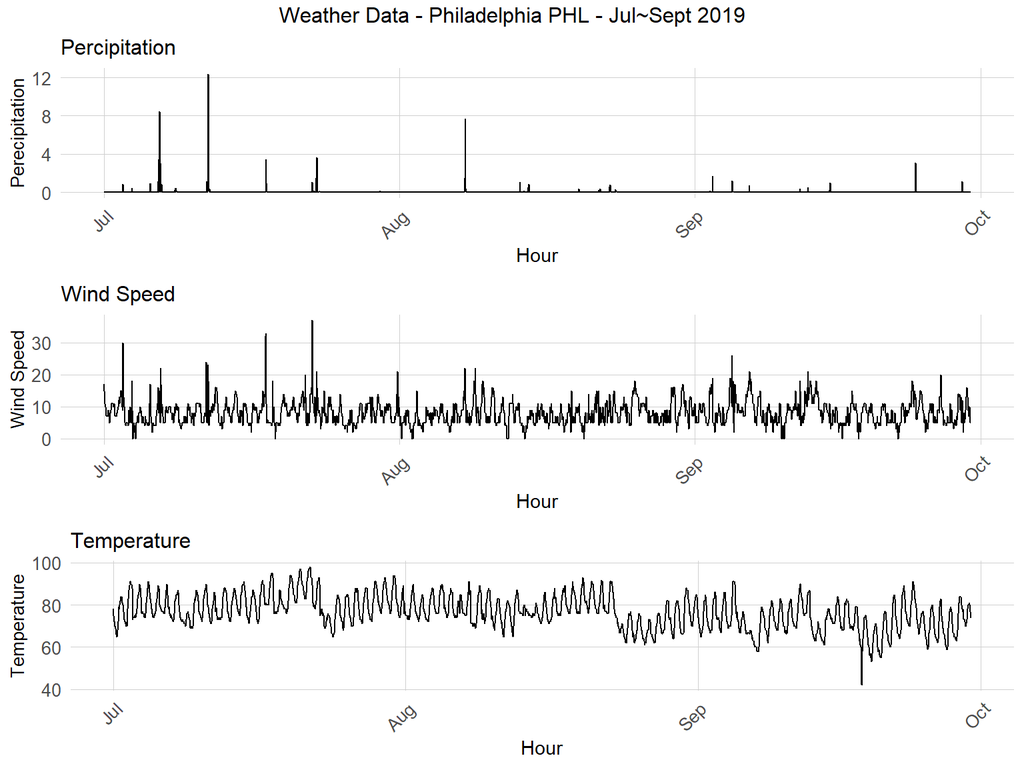

```r
grid.arrange(
  ggplot(Weather.Panel, aes(interval60,Precipitation)) + geom_line() +
    labs(title="Percipitation", x="Hour", y="Perecipitation") + plotTheme,
  ggplot(Weather.Panel, aes(interval60,Wind_Speed)) + geom_line() +
    labs(title="Wind Speed", x="Hour", y="Wind Speed") + plotTheme,
  ggplot(Weather.Panel, aes(interval60,Temperature)) + geom_line() +
    labs(title="Temperature", x="Hour", y="Temperature") + plotTheme,
  top="Weather Data - Philadelphia PHL - Jul~Sept 2019")
```

## 3. Exploratory Analysis

### 3.1 Create Space-Time Panel

The dataset for the forecast must be a complete panel, meaning there must be an observation for every possible space/time combination. Since the existing data frame is an incomplete panel with missing space/time intervals, in the code block below, the panel is completed by finding all unique space/time intervals, inserting `0` trips where necessary, and then performing some additional feature engineering.

```r
length(unique(Philly_dat_Census$interval60)) * length(unique(Philly_dat_Census$start_station))
```

```
## [1] 304014
```

An empty panel data frame ’study.panel`is created that has unique space/time observations. The complete`study.panel` includes totally 304,014 space/time units, which shows that the count is correct.

```r
study.panel <-
  expand.grid(interval60=unique(Philly_dat_Census$interval60),
              start_station = unique(Philly_dat_Census$start_station)) %>%
  left_join(., Philly_dat_Census %>%
              select(start_station, Origin.Tract, from_longitude, from_latitude )%>%
              distinct() %>%
              group_by(start_station) %>%
              slice(1))

nrow(study.panel)
```

```
## [1] 304014
```

Then, I created the full panel by summarizing counts by station for each time interval, keep census info and lat/lon information along for joining later to other data. The data for station IDs that are `FALSE` are removed. The output of the code block below ensures that a balanced panel is returned - one with an equal number of observations for each space/time combination:

```r
ride.panel <-
  Philly_dat_Census %>%
  mutate(Trip_Counter = 1) %>%
  right_join(study.panel) %>%
  group_by(interval60, start_station, Origin.Tract, from_longitude, from_latitude) %>%
  summarize(Trip_Count = sum(Trip_Counter, na.rm=T)) %>%
  left_join(Weather.Panel) %>%
  ungroup() %>%
  filter(is.na(start_station) == FALSE) %>%
  mutate(week = week(interval60),
         dotw = wday(interval60, label = TRUE)) %>%
  filter(is.na(Origin.Tract) == FALSE)

ride.panel <-
  left_join(ride.panel, PhillyCensus %>%
              as.data.frame() %>%
              select(-geometry), by = c("Origin.Tract" = "GEOID"))
```

### 3.2 Create Time-Lag

Next, some additional feature engineering is undertaken to mine the data for critical time trends. Like spatial lags, time lags are incredibly important when predicting time series trends. To capture these trends, several different time lags are created. Two holiday fixed effects are created for Independence Day and Labor Day as well, with the hypothesis that ride share patterns will certainly change around national holidays.

```r
ride.panel <-
  ride.panel %>%
  arrange(start_station, interval60) %>%
  mutate(lagHour = dplyr::lag(Trip_Count,1),
         lag2Hours = dplyr::lag(Trip_Count,2),
         lag3Hours = dplyr::lag(Trip_Count,3),
         lag4Hours = dplyr::lag(Trip_Count,4),
         lag12Hours = dplyr::lag(Trip_Count,12),
         lag1day = dplyr::lag(Trip_Count,24),
         holiday = ifelse(yday(interval60) %in% c(185, 245),1,0)) %>%
         #holiday = ifelse(yday(interval60) == 185,1,0), # 7/4 Independence Day
         #holiday = ifelse(yday(interval60) == 245,1,0)) %>% # 9/2 Labor Day
  mutate(day = yday(interval60)) %>%
  mutate(holidayLag = case_when(dplyr::lag(holiday, 1) == 1 ~ "PlusOneDay",
                                dplyr::lag(holiday, 2) == 1 ~ "PlustTwoDays",
                                dplyr::lag(holiday, 3) == 1 ~ "PlustThreeDays",
                                dplyr::lead(holiday, 1) == 1 ~ "MinusOneDay",
                                dplyr::lead(holiday, 2) == 1 ~ "MinusTwoDays",
                                dplyr::lead(holiday, 3) == 1 ~ "MinusThreeDays"),
         holidayLag = replace_na(holidayLag, 0))

# table(ride.panel$week[ride.panel$holidayLag != 0])
```

### 3.3 Trip Count Explore Analysis & Data Visualization

After feature engineering, in this section, I would like to look at how bike share trips vary by week, time in the day, and station.

#### 3.3.1 Temporal Pattern

At first, the time and frequency components of the data were examined.

#### Plot 1. Bike share trips per hr

The first plot indicates the overall time pattern - there is clearly a daily periodicity and there are lull periods on weekends.

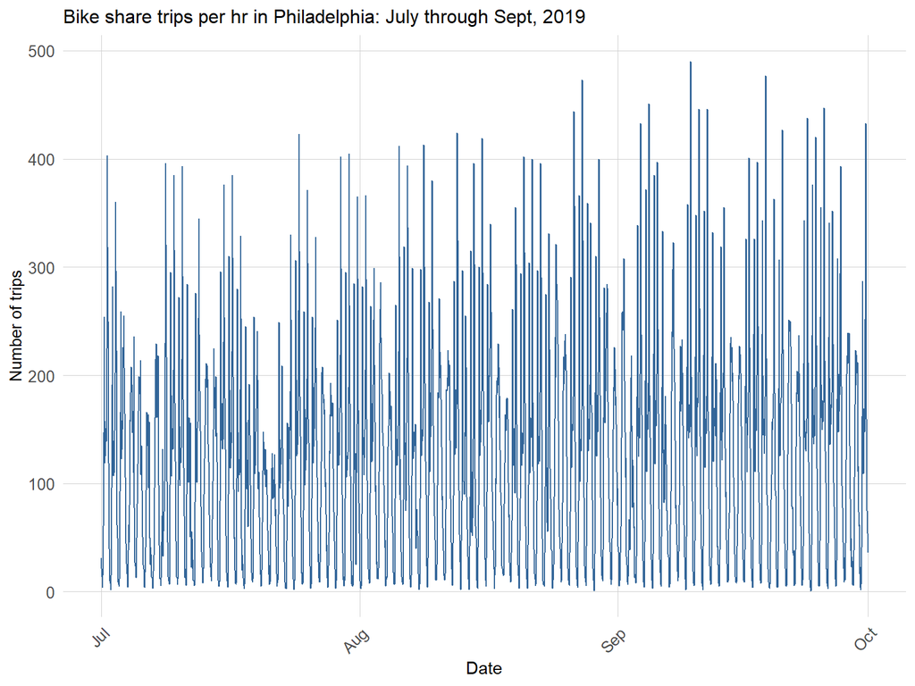

```r
ggplot(Philly_dat_Census %>%
         group_by(interval60) %>%
         tally())+
  geom_line(aes(x = interval60, y = n), colour="#336699")+ # change color
  labs(title="Bike share trips per hr in Philadelphia: July through Sept, 2019",
       x="Date",
       y="Number of trips")+
  plotTheme
```

#### Plot 2. Bike share trips by week

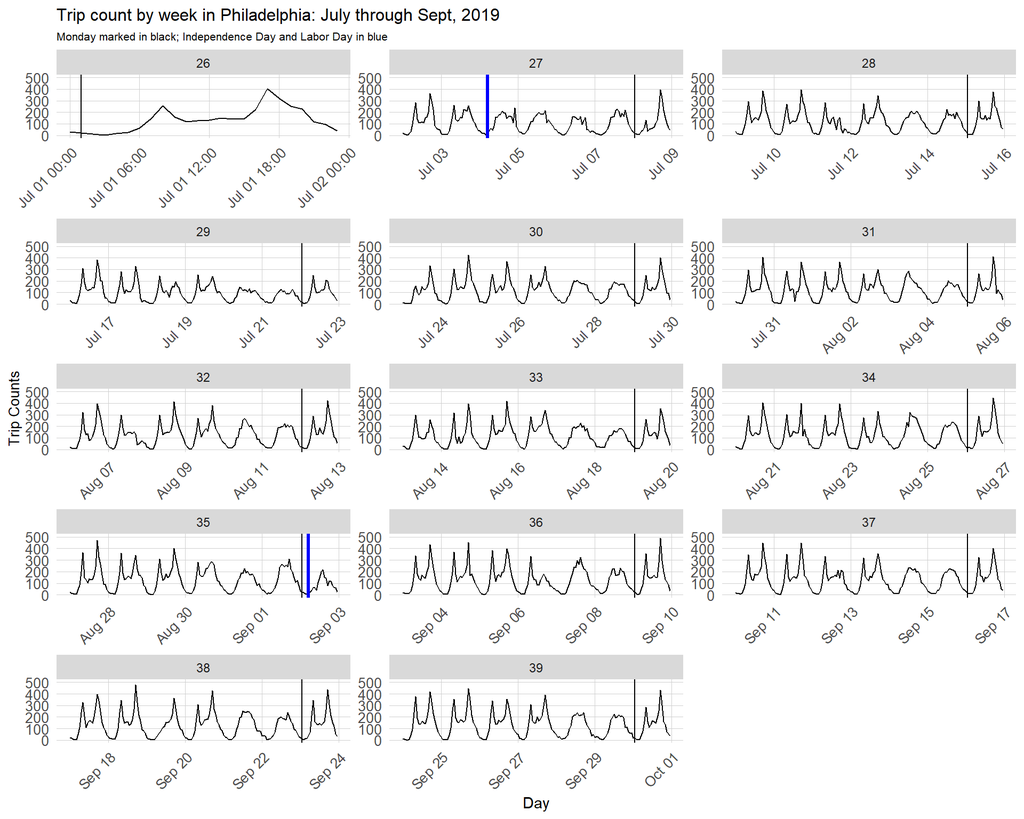

```r
mondayMidnight <-
  ride.panel %>%
  mutate(mondayMidnight = ifelse(wday(interval60) == 2 & hour(interval60) == 1,
                                 as.POSIXct(interval60),0)) %>%
  filter(mondayMidnight != 0)

as.data.frame(ride.panel) %>%
  group_by(week, interval60) %>%
  summarize(Trip_Count = sum(Trip_Count)) %>%
  ggplot(aes(interval60,Trip_Count)) +
  geom_line() +
  plotTheme +
  facet_wrap(~week, scales="free", ncol=3) +
  ylim(0,500) +
  labs(title="Trip count by week in Philadelphia: July through Sept, 2019",
       subtitle="Monday marked in black; Independence Day and Labor Day in blue", x="Day", y="Trip Counts") +
  geom_vline(xintercept = as.POSIXct("2019-07-04 01:00:00 UTC"),color = "blue",size=1.1) +
  geom_vline(xintercept = as.POSIXct("2019-09-02 01:00:00 UTC"),color = "blue",size=1.1) +
  geom_vline(data = mondayMidnight, aes(xintercept = mondayMidnight), colour="black")
```

#### Plot 3. Mean numbers of hourly trips per station & Plot 4. Bike share trips per HOUR by STATION

The third and fourth plots examine the distribution of trip volume by station for different times of the day. We clearly have a few high volume periods but mostly low volume. Our data must consist of a lot of low demand station/hours and a few high demand station hours. In fact, Plot 4 shows that more than 3/4 of the stations have less than 5 bike share trips per hour.

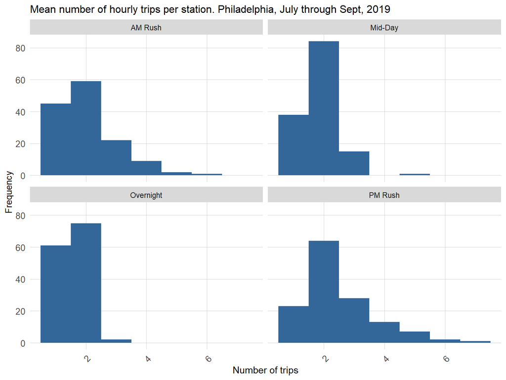

```r
Philly_dat_Census %>%
  mutate(time_of_day = case_when(hour(interval60) < 7 | hour(interval60) > 18 ~ "Overnight",
                                 hour(interval60) >= 7 & hour(interval60) < 10 ~ "AM Rush",
                                 hour(interval60) >= 10 & hour(interval60) < 15 ~ "Mid-Day",
                                 hour(interval60) >= 15 & hour(interval60) <= 18 ~ "PM Rush"))%>%
  group_by(interval60, start_station, time_of_day) %>%
  tally()%>%
  group_by(start_station, time_of_day)%>%
  summarize(mean_trips = mean(n))%>%
  ggplot()+
  geom_histogram(aes(mean_trips), binwidth = 1,fill='#336699')+ # change color!!!
  labs(title="Mean number of hourly trips per station. Philadelphia, July through Sept, 2019",
       x="Number of trips",
       y="Frequency")+
  facet_wrap(~time_of_day)+
  plotTheme
```

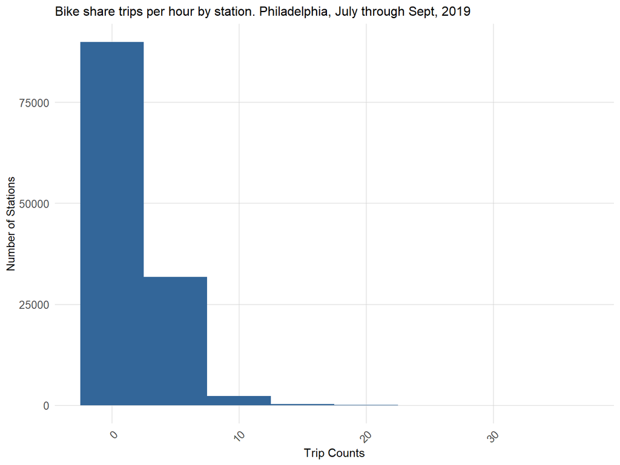

```r
ggplot(Philly_dat_Census %>%
         group_by(interval60, start_station) %>%
         tally())+ #Summarize
  geom_histogram(aes(n), binwidth = 5,fill='#336699')+ # change color
  labs(title="Bike share trips per hour by station. Philadelphia, July through Sept, 2019",
       x="Trip Counts",
       y="Number of Stations")+
  plotTheme
```

#### Plot 5. Bike share trips by day of the week

Then, I plot the ridershare trips count by day of the week, it is clearly that there exists a significant difference in the count of ridershare trips between weekdays and weekends. Also, the count of rideshare trips increased sharply during the morning and evening peak of weekdays.In addition, we can see bike share trips take place more on Monday and Tuesday during 15:00- 20:00 which includes the PM rush hours.

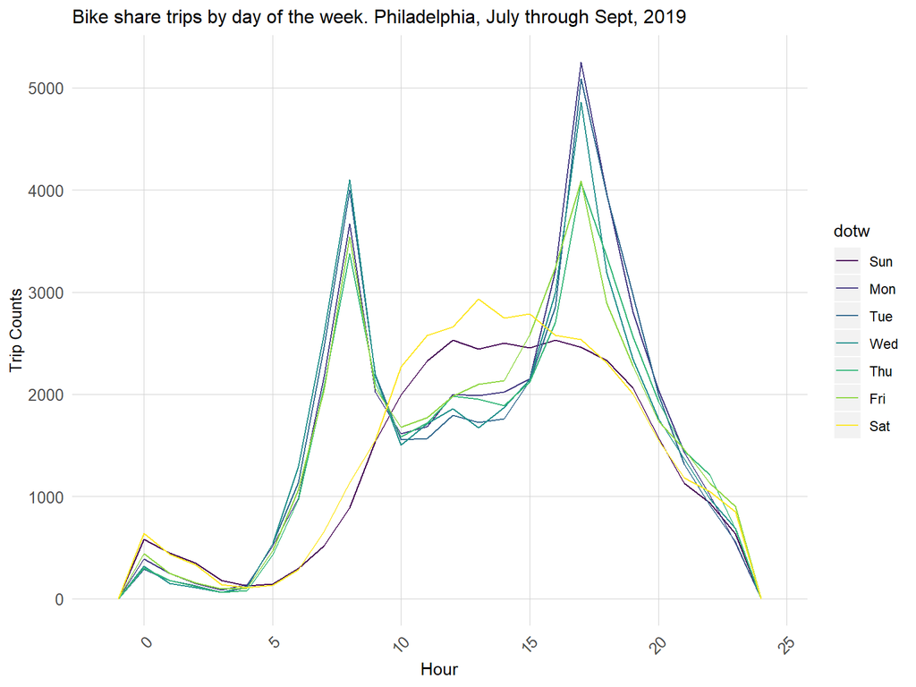

```r
ggplot(Philly_dat_Census %>% mutate(hour = hour(starttime)))+
  geom_freqpoly(aes(hour, color = dotw), binwidth = 1)+
  labs(title="Bike share trips by day of the week. Philadelphia, July through Sept, 2019",
       x="Hour",
       y="Trip Counts")+
  plotTheme
```

#### Plot 6. Bike share tips: WEEKEND VS WEEKDAY

In general, weekdays have more bike share trips than weekend. Besides, in weekends, more trips take place from 10:00 to 15:00, we can assume that it is due to more recreational activities.

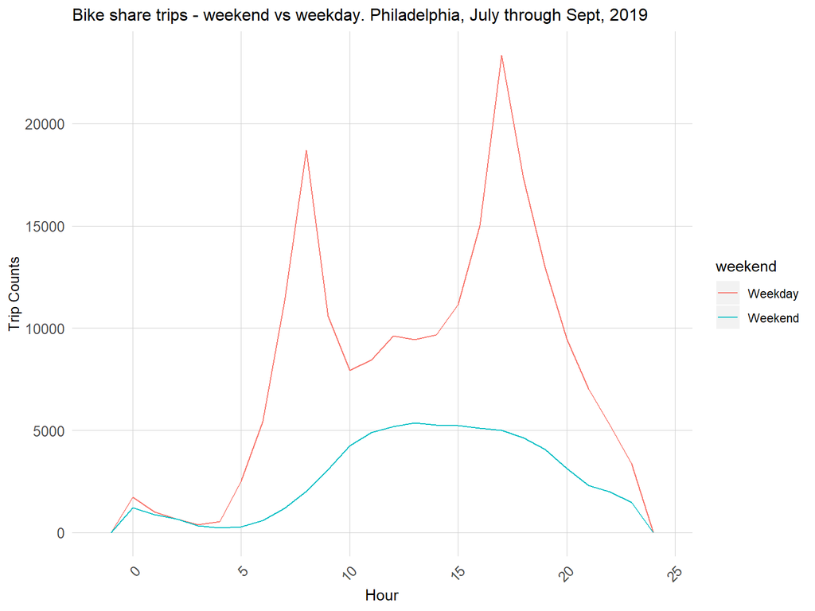

```r
ggplot(Philly_dat_Census %>%
         mutate(hour = hour(starttime),
                weekend = ifelse(dotw %in% c("Sun", "Sat"), "Weekend", "Weekday")))+
  geom_freqpoly(aes(hour, color = weekend), binwidth = 1)+
  labs(title="Bike share trips - weekend vs weekday. Philadelphia, July through Sept, 2019",
       x="Hour",
       y="Trip Counts")+
  plotTheme
```

#### Plot 7. Bike share trips per time slot by station

Furthermore, we can also map the bike share trips per time slot by stations to have a straightforward observation. The code block below divides the data into weekday and weekend. It is clear to see that on weekdays, bike share trips occur more during PM rush hours in Center City. While on weekends, more bike share trips seem to happen during mid-day. Additionally, bike share trips occur much fewer in count and less concentrated in physical space.

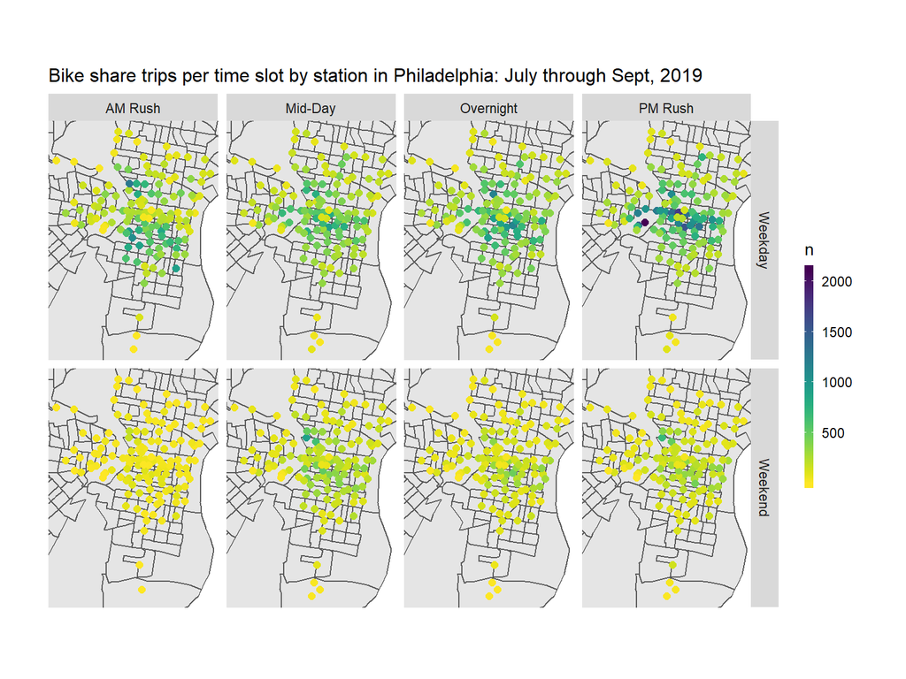

```r
ggplot()+
  geom_sf(data = PhillyTracts %>%
            st_transform(crs=4326))+
  geom_point(data = Philly_dat_Census %>%
               mutate(hour = hour(starttime),
                      weekend = ifelse(dotw %in% c("Sun", "Sat"), "Weekend", "Weekday"),
                      time_of_day = case_when(hour(interval60) < 7 | hour(interval60) > 18 ~ "Overnight",
                                              hour(interval60) >= 7 & hour(interval60) < 10 ~ "AM Rush",
                                              hour(interval60) >= 10 & hour(interval60) < 15 ~ "Mid-Day",
                                              hour(interval60) >= 15 & hour(interval60) <= 18 ~ "PM Rush"))%>%
               group_by(start_station, from_latitude, from_longitude, weekend, time_of_day) %>%
               tally(),
             aes(x=from_longitude, y = from_latitude, color = n),
             fill = "transparent", alpha = 1, size = 2)+
  scale_colour_viridis(direction = -1,
                       discrete = FALSE, option = "D")+
  ylim(min(Philly_dat_Census$from_latitude), max(Philly_dat_Census$from_latitude))+
  xlim(min(Philly_dat_Census$from_longitude), max(Philly_dat_Census$from_longitude))+
  facet_grid(weekend ~ time_of_day)+
  labs(title="Bike share trips per time slot by station in Philadelphia: July through Sept, 2019")+
  mapTheme
```

#### 3.3.2 Spatial Pattern

After examine the temporal pattern of bike share trips in Philly, we can also visualize the spatial distribution of the trip counts to understand if there are systematic rideshare patterns across spaces that can be harnessed when forecasting.

#### Plot 1. Sum of rideshare trips by tract and week

When I map the total number of rideshare trips by census tract and week, I find that: except for Week 26 which only covers one day of our study period, the spatial pattern for the rest of weeks looks similar even though Week 28-30, 37-38 seem having fewer trips than other weeks.

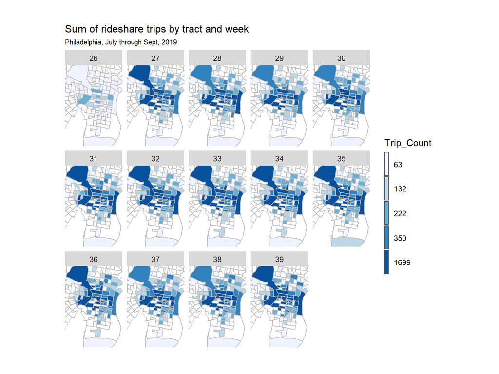

```r
ride.panel_tract <-
  left_join(ride.panel, PhillyTracts, by = c("Origin.Tract" = "GEOID")) %>%
  st_sf()

#temp.DataFrame <- ride.panel_tract %>%
 # group_by(week, Origin.Tract) %>%
  #summarize(Sum_Trip_Count = sum(Trip_Count))
#qBr(temp.DataFrame, "Sum_Trip_Count")

ride.panel_tract %>%
  group_by(week, Origin.Tract) %>%
  summarize(Sum_Trip_Count = sum(Trip_Count)) %>%
  ggplot() + geom_sf(aes(fill = q5(Sum_Trip_Count))) +
  facet_wrap(~week, ncol = 5) +
  scale_fill_manual(values = palette5,
                    labels = c("63","132", "222", "350", "1699"),
                    name = "Trip_Count") +
  ylim(min(Philly_dat_Census$from_latitude), max(Philly_dat_Census$from_latitude))+
  xlim(min(Philly_dat_Census$from_longitude), max(Philly_dat_Census$from_longitude))+
  labs(title="Sum of rideshare trips by tract and week",
       subtitle='Philadelphia, July through Sept, 2019') +
  geom_sf(data=PhillyTracts,color = "grey", fill = "transparent") +
  mapTheme
```

#### Plot 2. Sum of rideshare trips by tract and day of the week

And when visualizing the spatial distribution of trip counts by day of the week, I found that there are significant differences between weekdays and weekends.During weekdays, Monday, Tuesday and Friday have more bike share trips than Wednesday and Thursday. During all seven days in a week, most trips seem to be originated from the Center City.

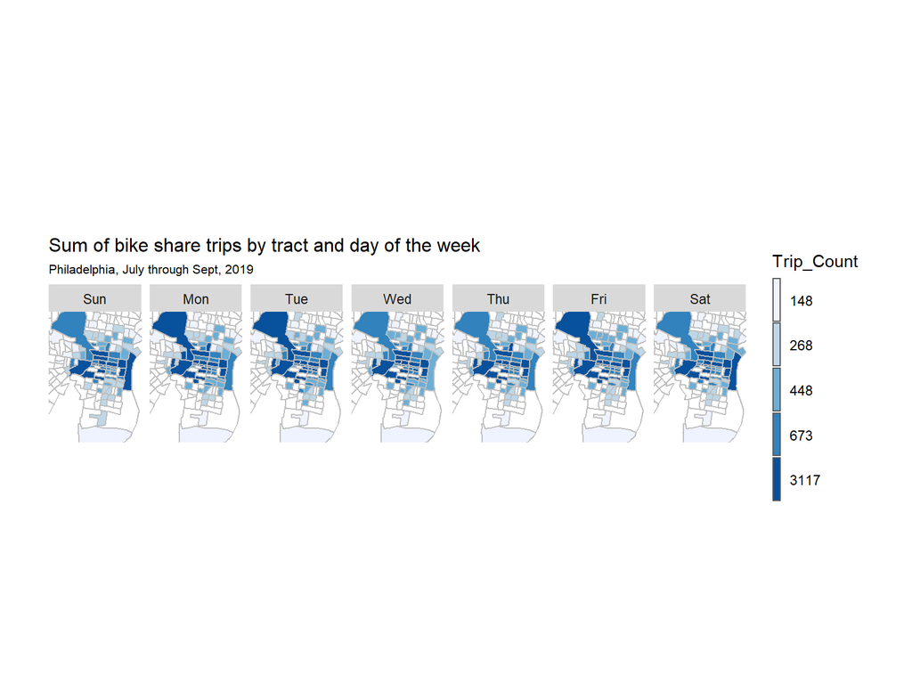

```r
#temp.DataFrame <- ride.panel_tract %>%
 # group_by(dotw, Origin.Tract) %>%
  #summarize(Sum_Trip_Count = sum(Trip_Count))
#qBr(temp.DataFrame, "Sum_Trip_Count")

ride.panel_tract %>%
  group_by(dotw, Origin.Tract) %>%
  summarize(Sum_Trip_Count = sum(Trip_Count)) %>%
  ggplot() + geom_sf(aes(fill = q5(Sum_Trip_Count))) +
  facet_wrap(~dotw, ncol = 7) +
  scale_fill_manual(values = palette5,
                    labels = c("148","268", "448", "673", "3117"),
                    name = "Trip_Count") +
  ylim(min(Philly_dat_Census$from_latitude), max(Philly_dat_Census$from_latitude))+
  xlim(min(Philly_dat_Census$from_longitude), max(Philly_dat_Census$from_longitude))+
  labs(title="Sum of bike share trips by tract and day of the week",
       subtitle='Philadelphia, July through Sept, 2019') +
  geom_sf(data=PhillyTracts,color = "grey", fill = "transparent") +
  mapTheme
```

#### Plot 3. Sum of rideshare trips by tract and hour of the day

When I examine the spatial pattern of bike share trips per hour, I found that there’s a clear difference and transition between nighttime and mornings, starting from Center City. In fact, there’re just few trips during 10PM-6AM, some but not too many tripd during 6AM-10AM & 8PM-10PM, and 11AM-7PM has the most number of bike share trips in a day. 5PM seems to have the highest bike share service usage rate.

[figure not shown]

```r
#temp.DataFrame <- ride.panel_tract %>%
 # group_by(hour = hour(interval60), Origin.Tract) %>%
  #summarize(Sum_Trip_Count = sum(Trip_Count))
#qBr(temp.DataFrame, "Sum_Trip_Count")

ride.panel_tract %>%
  group_by(hour = hour(interval60), Origin.Tract) %>%
  summarize(Sum_Trip_Count = sum(Trip_Count)) %>%
  ggplot() + geom_sf(aes(fill = q5(Sum_Trip_Count))) +
  facet_wrap(~hour, ncol = 8) +
  scale_fill_manual(values = palette5,
                    labels = c("19","52", "106", "222", "3308"),
                    name = "Trip_Count") +
  ylim(min(Philly_dat_Census$from_latitude), max(Philly_dat_Census$from_latitude))+
  xlim(min(Philly_dat_Census$from_longitude), max(Philly_dat_Census$from_longitude))+
  labs(title="Sum of bike share trips by tract and day of the week",
       subtitle='Philadelphia, July through Sept, 2019') +
  geom_sf(data=PhillyTracts,color = "grey", fill = "transparent") +
  mapTheme
```

#### 3.3.3 Space/Time Animation

Furthermore, we can build an animated gif map of rideshare trips over both space and time. Week 34 & 36 which have large number of bike share trip counts are chosen to help explore the relationship. I design the time intervals as 15 minutes for Week 36 and 60 minutes for Week 34. They better show the spatial-temporal pattern of Indego bike share services than those still graphs that: **1) those trips centralized in the central part of Philadelphia, especially Center City areas 2) the time period around PM peak hours has the most number of bike share trips in a day.**

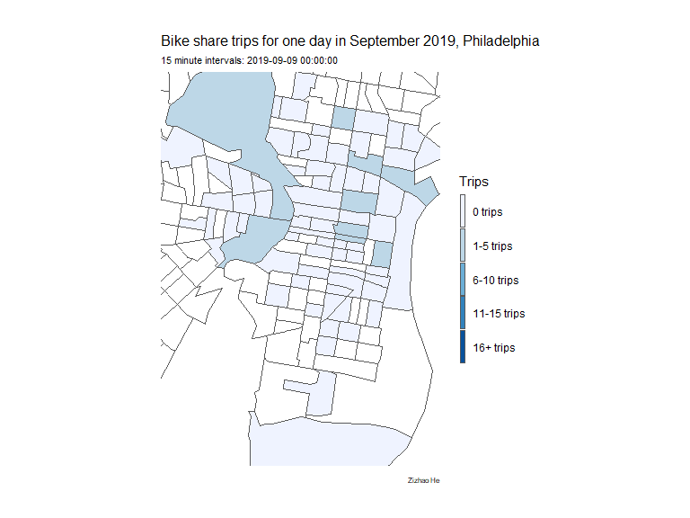

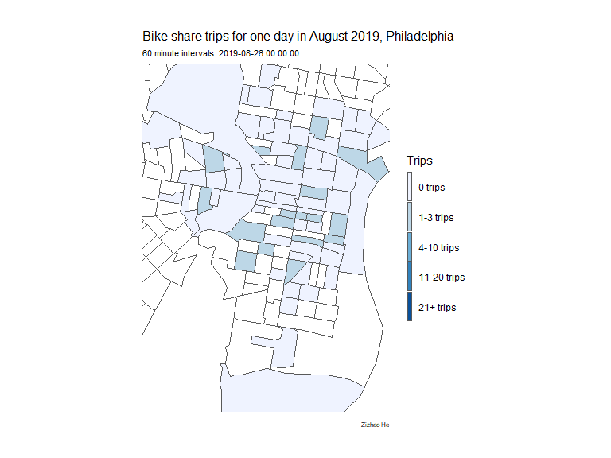

```r
# Week 36--15 minute intervals
week36<-
  Philly_dat_Census %>%
  filter(week == 36 & dotw == "Mon")

week36.panel <-
  expand.grid(
    interval15=unique(week36$interval15),
    Origin.Tract = unique(week36$Origin.Tract))

#temp.DataFrame <- week36 %>%
 # mutate(Trip_Counter = 1) %>%
  #right_join(week36.panel) %>%
  #group_by(interval15, Origin.Tract) %>%
  #summarize(Trip_Count = sum(Trip_Counter, na.rm=T))
#table(temp.DataFrame$Trip_Count)

ride.animation.data <-
  week36 %>%
  mutate(Trip_Counter = 1) %>%
  right_join(week36.panel) %>%
  group_by(interval15, Origin.Tract) %>%
  summarize(Trip_Count = sum(Trip_Counter, na.rm=T)) %>%
  left_join(PhillyTracts,by=c("Origin.Tract" = "GEOID")) %>%
  st_sf() %>%
  mutate(Trips = case_when(Trip_Count == 0 ~ "0 trips",
                           Trip_Count > 0 & Trip_Count <= 5 ~ "1-5 trips",
                           Trip_Count > 5 & Trip_Count <= 10 ~ "6-10 trips",
                           Trip_Count > 10 & Trip_Count <= 15 ~ "11-15 trips",
                           Trip_Count > 15 ~ "16+ trips")) %>%
  mutate(Trips  = factor(Trips, levels=c("0 trips","1-5 trips","6-10 trips","11-15 trips","16+ trips")))

rideshare_animation <-
  ggplot() +
  geom_sf(data=ride.animation.data, aes(fill=Trips)) +
  scale_fill_manual(values = palette5) +
  ylim(min(Philly_dat_Census$from_latitude), max(Philly_dat_Census$from_latitude))+
  xlim(min(Philly_dat_Census$from_longitude), max(Philly_dat_Census$from_longitude))+
  labs(title = "Bike share trips for one day in September 2019, Philadelphia",
       subtitle = "15 minute intervals: {current_frame}", caption = "Zizhao He") +
  transition_manual(interval15) +
  geom_sf(data=PhillyTracts,fill = "NA") +
  mapTheme

animate(rideshare_animation, duration=20)
```

#### 3.3.4 Other Exploratory Analysis Results (with other factors)

After explored the characteristics of bike share trip count itself, in this section, I started to learn the relationship between trip count and other variables.

- Time Lags

```r
RP.lag<-as.data.frame(ride.panel) %>%
  group_by(interval60) %>%
  summarise_at(c(vars(starts_with("lag"), "Trip_Count")), mean, na.rm = TRUE) %>%
  gather(Variable, Value, -interval60, -Trip_Count) %>%
  mutate(Variable = factor(Variable, levels=c("lagHour","lag2Hours","lag3Hours","lag4Hours",
                                              "lag12Hours","lag1day")))
correlation.lag <-
  RP.lag %>%
  group_by(Variable) %>%
  summarize(correlation = round(cor(Value, Trip_Count),2))

correlation.lag %>%
  kable(caption = "Correlation between trip count and time lags") %>%
  kable_styling("striped", full_width = F) %>%
  row_spec(1, color = "black", background = "#CFC0D1")%>%
  row_spec(3, color = "black", background = "#CFC0D1")%>%
  row_spec(5, color = "black", background = "#CFC0D1")
```

Correlation between trip count and time lags

| Variable | correlation |
| --- | --- |
| lagHour | 0.81 |
| lag2Hours | 0.56 |
| lag3Hours | 0.35 |
| lag4Hours | 0.17 |
| lag12Hours | -0.45 |
| lag1day | 0.80 |

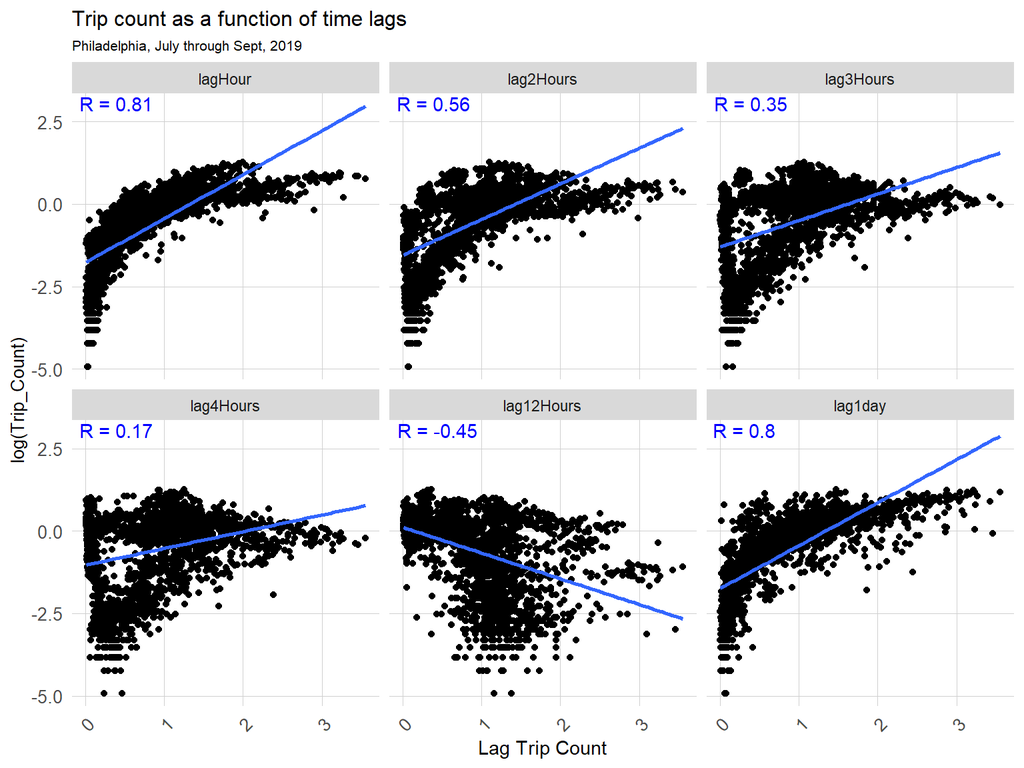

```r
# Correlation with plot
ggplot(RP.lag, aes(Value,log(Trip_Count))) + geom_point() + geom_smooth(method="lm", se = F) +
  facet_wrap(~Variable) +
  geom_text(data=correlation.lag, aes(label=paste("R =", correlation)),
            colour = "blue", x=-Inf, y=Inf, hjust=-0.1, vjust=1.2) +
  plotTheme+
  labs(title="Trip count as a function of time lags",
       subtitle="Philadelphia, July through Sept, 2019", x = "Lag Trip Count")
```

As the table and plots shown, the effects that bike share trip counts as a function of the various time lags are very strong. It’s interesting to see that the correlation **decreases with each addition hour**. However, the predictive power returns with the 24-hour lag. What’s more, these plots indicate time effects most certainly play a vital role in forecasting ride share!

- Weather Factors

Then, the effects of weather factors (`precipation`, `temperature`, `wind speed`) on the use of the bike share program was examined.

`Precipation`

As shown in the plots below, it does not neccessarily support the hypothesis that rain and snow increase the propensity to take rideshare. In most weeks of the study period, the demand for bike share decreases in rainy/snowy day.

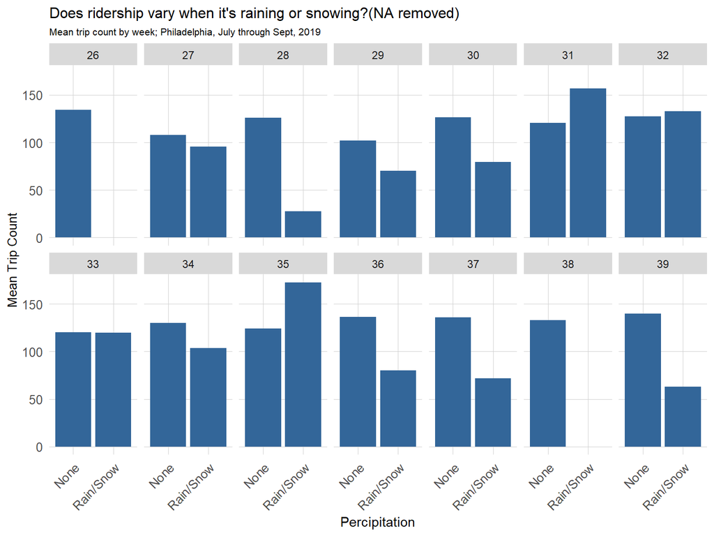

```r
# 1) Precipitation
as.data.frame(ride.panel) %>%
  group_by(interval60) %>%
  summarize(Trip_Count = sum(Trip_Count)) %>%
  left_join(Weather.Panel) %>%
  mutate(isPercip = ifelse(Precipitation > 0, "Rain/Snow", "None")) %>%
  na.omit()%>%
  group_by(week = week(interval60), isPercip) %>%
  summarize(Mean_Trip_Count = mean(Trip_Count)) %>%
  ggplot(aes(isPercip, Mean_Trip_Count)) +
  geom_bar(stat = "identity",fill="#336699") +
  facet_wrap(~week,ncol=7) +
  labs(title="Does ridership vary when it's raining or snowing?(NA removed)",
       subtitle="Mean trip count by week; Philadelphia, July through Sept, 2019",
       x="Percipitation", y="Mean Trip Count") +
  plotTheme + theme(axis.text.x = element_text(angle = 45, hjust = 1))
```

`Temperature`

**Do more people take ride share when it’s colder?** The small multiple plots of bike share trip count as a function of temperature by week suggest the opposite - that ride share actually increases as temperatures get warmer!

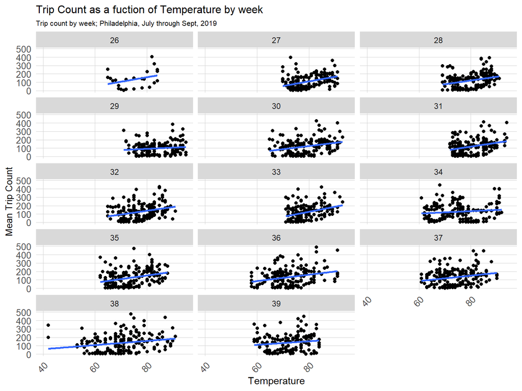

```r
# 2) Temperature
as.data.frame(ride.panel) %>%
  group_by(interval60) %>%
  summarize(Trip_Count = sum(Trip_Count)) %>%
  left_join(Weather.Panel) %>%
  mutate(week = week(interval60)) %>%
  na.omit()%>%
  ggplot(aes(Temperature, Trip_Count)) +
  geom_point() + facet_wrap(~week, ncol=3) + geom_smooth(method = "lm", se= FALSE) +
  xlim(40,95)+
  plotTheme +
  labs(title="Trip Count as a fuction of Temperature by week",
       subtitle="Trip count by week; Philadelphia, July through Sept, 2019",
       x="Temperature", y="Mean Trip Count")
```

`Wind Speed`

How about wind speed? The plots show that except for Week 26, the bike share demand increases a little bit when it is more windy.

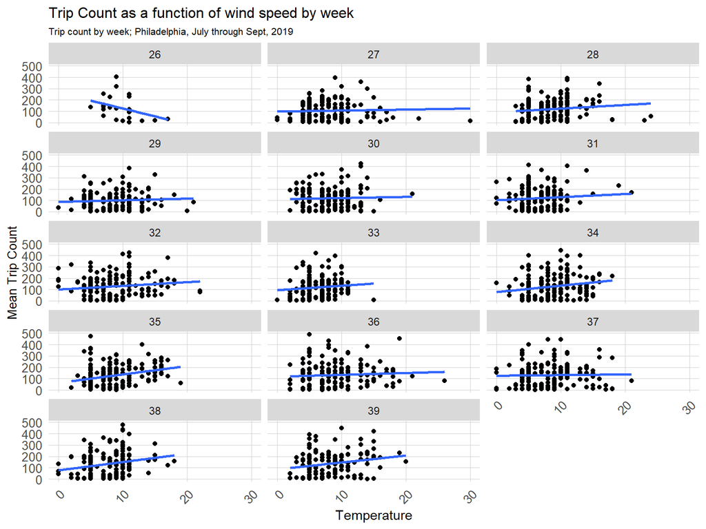

```r
# 3) Wind Speed
as.data.frame(ride.panel) %>%
  group_by(interval60) %>%
  summarize(Trip_Count = sum(Trip_Count)) %>%
  left_join(Weather.Panel) %>%
  mutate(week = week(interval60)) %>%
  na.omit()%>%
  ggplot(aes(Wind_Speed, Trip_Count)) +
  geom_point() + facet_wrap(~week,ncol=3) + geom_smooth(method = "lm", se= FALSE) +
  xlim(0,30)+
  plotTheme +
  labs(title="Trip Count as a function of wind speed by week",
       subtitle="Trip count by week; Philadelphia, July through Sept, 2019",
       x="Temperature", y="Mean Trip Count")
```

- Socio-economic Characteristics

Lastly, because of the space/time panel nature of the data, census data cannot be used in the forecast. Nevertheless, for the purpose of exploratory analysis, we can still briefly analyze correlation between trip count by census tract as a function of 5 census variables. The table and plots of correlation are shown as below.

```r
# Relationship: trip count from each census tract vs socio-economic
RP.census <-
  as.data.frame(ride.panel) %>%
  group_by(Origin.Tract) %>%
  summarize(Trip_Count = sum(Trip_Count))  %>%
  left_join(PhillyCensus, by=c("Origin.Tract" = "GEOID")) %>%
  dplyr::select(Med_Inc,
                Mean_Commute_Time,
                Percent_Taking_Public_Trans,
                Percent_White,
                Med_Age,
                Trip_Count) %>%
  gather(Variable, Value, -Trip_Count) %>%
  na.omit() %>%
  filter(Variable =="Med_Inc"| Variable == "Total_Pop"|Variable == "Percent_White"|
           Variable == "Mean_Commute_Time"|Variable == "Percent_Taking_Public_Trans"|Variable == "Med_Age")

# Correlation with table
correlation.census <-
  RP.census %>%
  group_by(Variable) %>%
  summarize(correlation = round(cor(Value, log(Trip_Count)),2))

correlation.census%>%
  kable(caption = "Trip count (log) as a function of socio-economic factors") %>%
  kable_styling("striped", full_width = F) %>%
  row_spec(1, color = "black", background = "#CFC0D1")%>%
  row_spec(3, color = "black", background = "#CFC0D1")%>%
  row_spec(5, color = "black", background = "#CFC0D1")
```

Trip count (log) as a function of socio-economic factors

| Variable | correlation |
| --- | --- |
| Mean_Commute_Time | 0.42 |
| Med_Age | 0.01 |
| Med_Inc | 0.52 |
| Percent_Taking_Public_Trans | -0.66 |
| Percent_White | 0.54 |

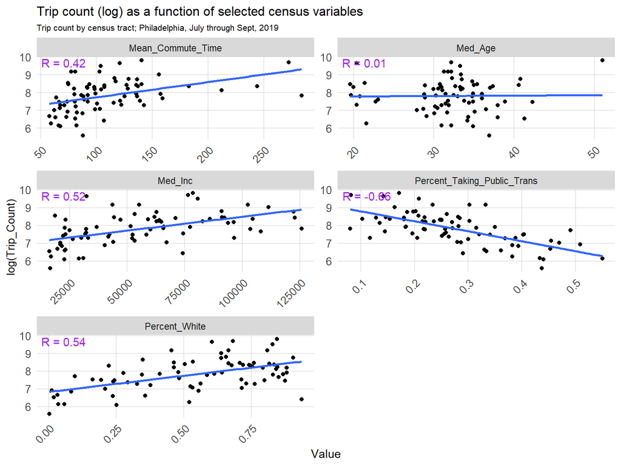

```r
# Correlation with plot
ggplot(RP.census, aes(Value,log(Trip_Count))) + geom_point() + geom_smooth(method="lm", se = F) +
  facet_wrap(~Variable, scales="free", ncol=2) +
  geom_text(data=correlation.census, aes(label=paste("R =", correlation)),
            colour = "purple", x=-Inf, y=Inf, hjust=-0.1, vjust=1.2) +
  plotTheme+
  labs(title="Trip count (log) as a function of selected census variables",
       subtitle="Trip count by census tract; Philadelphia, July through Sept, 2019")
```

## 4. Modeling

After conducting exploratory analysis with the variables, we had a preliminary understanding of the relationship between the use of the Indego bike share program in Philadelphia and the influence factors. In this section, the models would be built and run for predicting the distribution (time-space) patterns of the rideshare data.

### 4.1 Train and Test Sets Seperation

At first, the data was split into a training and a test set which are distinguished from Week 33 – there are totally 7 weeks in the test set. In the next section, several regressions are run and predictions are created in a nested data frame allowing to concisely validate each model.

```r
ride.Train <- filter(ride.panel, week < 33)
ride.Test <- filter(ride.panel, week >= 33)
```

### 4.2 Model Building and Estimation

In this step, 5 linear models are created using the “lm” function in the training set, but made predictions and get results in the test set. The reason why I don’t use an algorithm like Poisson over OLS even though the dependent variable (Trip Count) in the model is a count and not continuous is: **The counts are sufficiently large to feel at ease with OLS.**

Here is a breakdown of the 5 regressions estimated below:

Model 1: “reg1”, focuses on just time effects. The first model includes hour fixed effects, day of the week fixed effects and temperature. Lag effects are not included for now.

Model 2: “reg2”, replaces the time fixed effects with a vector of origin tracts fixed effects.

Model 3: “reg3”, includes both time and space fixed effects.

Model 4: “reg4”, adds the time lag features.

Model 5: “reg5”, adds holiday and holidayLag effects.

```r
reg1 <-
  lm(Trip_Count ~  hour(interval60) + dotw + Temperature,  data=ride.Train)

reg2 <-
  lm(Trip_Count ~  start_station + dotw + Temperature,  data=ride.Train)

reg3 <-
  lm(Trip_Count ~  start_station + hour(interval60) + dotw + Temperature + Precipitation,
     data=ride.Train)

reg4 <-
  lm(Trip_Count ~  start_station +  hour(interval60) + dotw + Temperature + Precipitation +
       lagHour + lag2Hours +lag3Hours + lag12Hours + lag1day, data=ride.Train)

reg5 <-
  lm(Trip_Count ~  start_station + hour(interval60) + dotw + Temperature + Precipitation +
       lagHour + lag2Hours +lag3Hours +lag12Hours + lag1day + holidayLag + holiday, data=ride.Train)
```

### 4.3 Test Data Prediction

Then, I created a nested data frame of test data by week. A function called `model_pred` which can be used to map onto each data frame in the nested structure was created as well. What makes the nested format so powerful, is the ability to loop through each week and mutate summary statistics for each model. In the code block below, `week_predictions` are calculated for each week in `ride.Test`. This accomplished by way of the `map` function, which is designed to apply a function to each element.

```r
ride.Test.weekNest <-
  ride.Test %>%
  nest(-week)

model_pred <- function(dat, fit){
  pred <- predict(fit, newdata = dat)}

week_predictions <-
  ride.Test.weekNest %>%
  mutate(ATime_FE = map(.x = data, fit = reg1, .f = model_pred),
         BSpace_FE = map(.x = data, fit = reg2, .f = model_pred),
         CTime_Space_FE = map(.x = data, fit = reg3, .f = model_pred),
         DTime_Space_FE_timeLags = map(.x = data, fit = reg4, .f = model_pred),
         ETime_Space_FE_timeLags_holidayLags = map(.x = data, fit = reg5, .f = model_pred)) %>%
  gather(Regression, Prediction, -data, -week) %>%
  mutate(Observed = map(data, pull, Trip_Count),
         Absolute_Error = map2(Observed, Prediction,  ~ abs(.x - .y)),
         MAE = map_dbl(Absolute_Error, mean, na.rm = TRUE),
         sd_AE = map_dbl(Absolute_Error, sd, na.rm = TRUE))

week_predictions
```

```
## # A tibble: 35 x 8
##     week          data Regression Prediction Observed Absolute_Error   MAE
##    <dbl> <list<df[,29> <chr>      <list>     <list>   <list>         <dbl>
##  1    33 [23,184 x 29] ATime_FE   <dbl [23,~ <dbl [2~ <dbl [23,184]> 0.984
##  2    34 [23,184 x 29] ATime_FE   <dbl [23,~ <dbl [2~ <dbl [23,184]> 1.03
##  3    35 [23,184 x 29] ATime_FE   <dbl [23,~ <dbl [2~ <dbl [23,184]> 1.02
##  4    36 [23,184 x 29] ATime_FE   <dbl [23,~ <dbl [2~ <dbl [23,184]> 1.05
##  5    37 [23,184 x 29] ATime_FE   <dbl [23,~ <dbl [2~ <dbl [23,184]> 1.03
##  6    38 [22,770 x 29] ATime_FE   <dbl [22,~ <dbl [2~ <dbl [22,770]> 1.04
##  7    39 [23,046 x 29] ATime_FE   <dbl [23,~ <dbl [2~ <dbl [23,046]> 1.07
##  8    33 [23,184 x 29] BSpace_FE  <dbl [23,~ <dbl [2~ <dbl [23,184]> 0.990
##  9    34 [23,184 x 29] BSpace_FE  <dbl [23,~ <dbl [2~ <dbl [23,184]> 1.03
## 10    35 [23,184 x 29] BSpace_FE  <dbl [23,~ <dbl [2~ <dbl [23,184]> 1.00
## # ... with 25 more rows, and 1 more variable: sd_AE <dbl>
```

## 5. Results & Examination

After running the predictions, the results from all 5 models were got in the end of the previous section. In this section, the results would be examined in the aspects of **accuracy** and **generalizability**.

### 5.1 Examine Error Metrics for Accuracy

The best models - the lag models (in general, they have the smallest MAE among all models), are accurate to less than an average of one ride per hour, at a glance, that’s pretty alright for overall accuracy.

The MAE is plotted by model specifification for each week below. We see that the holiday effects do not bring much additional predictive power to the model, except for Week 35 & 36. In the other weeks, holiday effects make the prediction less accurate. Note that both the training and test has one holiday. However, the fact shows that holiday effects do not work well.

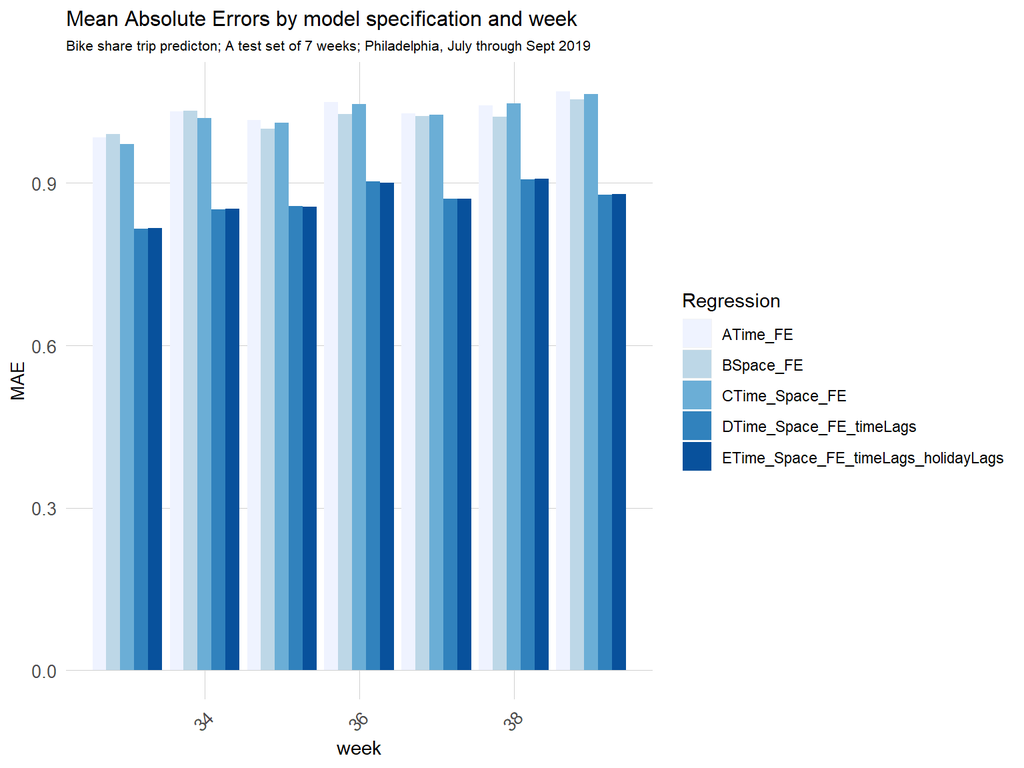

```r
# MAE by model specification and week
week_predictions %>%
  dplyr::select(week, Regression, MAE) %>%
  gather(Variable, MAE, -Regression, -week) %>%
  ggplot(aes(week, MAE)) +
  geom_bar(aes(fill = Regression), position = "dodge", stat="identity") +
  scale_fill_manual(values = palette5) +
  labs(title = "Mean Absolute Errors by model specification and week",
       subtitle = "Bike share trip predicton; A test set of 7 weeks; Philadelphia, July through Sept 2019") +
  plotTheme
```

In addition, for each model, the predicted and observed trip count is plotted in time series form below. Probably the simple, most all-encompassing interpretation of the results below is that with increasing sophistication, it becomes increasingly possible to predict well for the trip count spikes.

According to the plots, the spatial fixed effects alone don’t help predict the time trend. Models A and C that include time and time/space fixed effects respectively, appear to be have the same time trends because in this plot, all the predictions are aggregated from their spatial context to time alone.

It is also clear to see time lag effects add a tremendous amount of predictive power to this model, very nearly predicting the highest spikes. Not surprisingly, bike share patterns from the very recent past do a great job predicting in the near future. But simply based on the plot, holiday effects don’t bring consipicuous predictive power either.

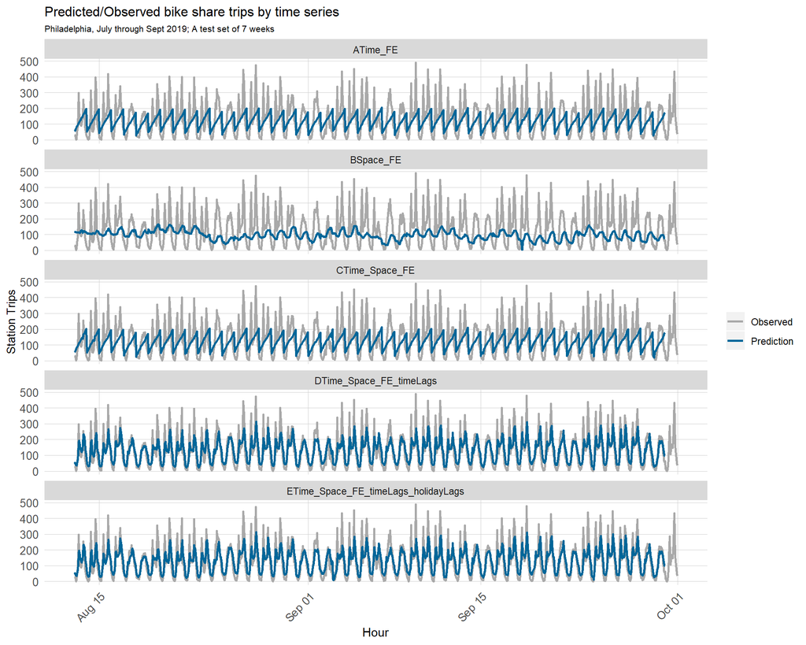

```r
# Predicted/Observed bike share time series
week_predictions %>%
  mutate(interval60 = map(data, pull, interval60),
         start_station = map(data, pull, start_station)) %>%
  dplyr::select(interval60, start_station, Observed, Prediction, Regression) %>%
  unnest() %>%
  gather(Variable, Value, -Regression, -interval60, -start_station) %>%
  group_by(Regression, Variable, interval60) %>%
  summarize(Value = sum(Value)) %>%
  ggplot(aes(interval60, Value, colour=Variable)) +
   scale_colour_manual("",values = c("Observed" = "darkgray","Prediction" = "#006699")) +
  geom_line(size = 1) +
  facet_wrap(~Regression, ncol=1) +
  labs(title = "Predicted/Observed bike share trips by time series",
       subtitle = "Philadelphia, July through Sept 2019; A test set of 7 weeks",
       x = "Hour", y= "Station Trips") +
  plotTheme
```

Therefore, through examining Mean Absolute Error (MAE) and the plot above, I believe **the fourth model** which has time lages but no holiday effects seems to have the best goodness of fit generally.

### 5.2 Generalizability

There are different dimensions to test the generalizability of the model (Model 4): time, space and socio-economic factors. The core question to be answered is: does the model predict well in different context of those dimensions?

#### 5.2.1 Validate test set by time

If we plot observed vs. predicted for different times of day during the week and weekend, as shown in the plots below, some patterns begin to emerge. However, we are certainly underpredicting in general.

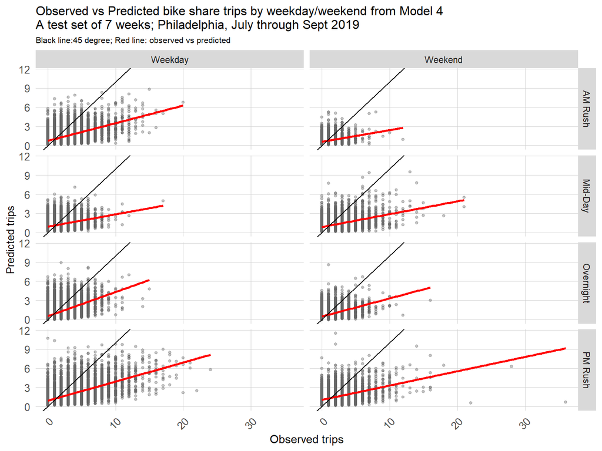

```r
# Observed vs Predicted bike share trips by weekday/weekend from Model 4
week_predictions %>%
  mutate(interval60 = map(data, pull, interval60),
         start_station = map(data, pull, start_station),
         from_latitude = map(data, pull, from_latitude),
         from_longitude = map(data, pull, from_longitude),
         dotw = map(data, pull, dotw)) %>%
  dplyr::select(interval60, start_station, from_longitude,
                from_latitude, Observed, Prediction, Regression,
                dotw) %>%
  unnest() %>%
  filter(Regression == "DTime_Space_FE_timeLags")%>%
  mutate(weekend = ifelse(dotw %in% c("Sun", "Sat"), "Weekend", "Weekday"),
         time_of_day = case_when(hour(interval60) < 7 | hour(interval60) > 18 ~ "Overnight",
                                 hour(interval60) >= 7 & hour(interval60) < 10 ~ "AM Rush",
                                 hour(interval60) >= 10 & hour(interval60) < 15 ~ "Mid-Day",
                                 hour(interval60) >= 15 & hour(interval60) <= 18 ~ "PM Rush"))%>%
  ggplot()+
  geom_point(aes(x= Observed, y = Prediction), size=1,alpha = 0.4,color="#666666")+
  geom_smooth(aes(x= Observed, y= Prediction), method = "lm", se = FALSE, color = "red")+
  geom_abline(slope = 1, intercept = 0)+
  facet_grid(time_of_day~weekend)+
  labs(title="Observed vs Predicted bike share trips by weekday/weekend from Model 4\nA test set of 7 weeks; Philadelphia, July through Sept 2019",
       x="Observed trips",
       y="Predicted trips",
       subtitle='Black line:45 degree; Red line: observed vs predicted')+
  plotTheme
```

So, it’s better to look at the errors on a map by weekend & weekday and time of day. WIt’s clear that weekends and weekdays have different error patterns in time. According to the maps, during weekdays, Central City tends to have more errors in AM rush and PM rush hours; while during weekends, Central City has more errors in Mid-Day and PM Rush, which means the predictive ability of the model does not perform well during these periods. In general, weekdays tend to have more errors than weekends in prediction.

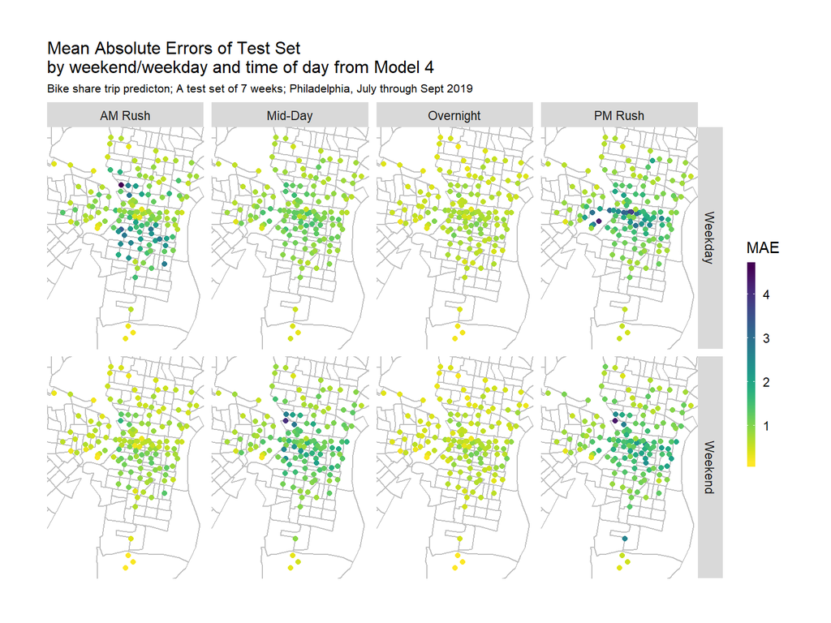

```r
# Mean Absolute Errors of Test Set \nby weekend/weekday and time of day from Model 4
week_predictions %>%
  mutate(interval60 = map(data, pull, interval60),
         start_station = map(data, pull, start_station),
         from_latitude = map(data, pull, from_latitude),
         from_longitude = map(data, pull, from_longitude),
         dotw = map(data, pull, dotw) ) %>%
  dplyr::select(interval60, start_station, from_longitude,
                from_latitude, Observed, Prediction, Regression,
                dotw) %>%
  unnest() %>%
  filter(Regression == "DTime_Space_FE_timeLags")%>%
  mutate(weekend = ifelse(dotw %in% c("Sun", "Sat"), "Weekend", "Weekday"),
         time_of_day = case_when(hour(interval60) < 7 | hour(interval60) > 18 ~ "Overnight",
                                 hour(interval60) >= 7 & hour(interval60) < 10 ~ "AM Rush",
                                 hour(interval60) >= 10 & hour(interval60) < 15 ~ "Mid-Day",
                                 hour(interval60) >= 15 & hour(interval60) <= 18 ~ "PM Rush")) %>%
  group_by(start_station, weekend, time_of_day, from_longitude, from_latitude) %>%
  summarize(MAE = mean(abs(Observed-Prediction), na.rm = TRUE))%>%
  ggplot(.)+
  geom_sf(data = PhillyCensus, color = "grey", fill = "transparent")+
  geom_point(aes(x = from_longitude, y = from_latitude, color = MAE),
             fill = "transparent", size = 1.5, alpha = 1)+
  scale_colour_viridis(direction = -1,
                       discrete = FALSE, option = "D")+
  ylim(min(Philly_dat_Census$from_latitude), max(Philly_dat_Census$from_latitude))+
  xlim(min(Philly_dat_Census$from_longitude), max(Philly_dat_Census$from_longitude))+
  facet_grid(weekend~time_of_day)+
  labs(title="Mean Absolute Errors of Test Set \nby weekend/weekday and time of day from Model 4",
       subtitle = "Bike share trip predicton; A test set of 7 weeks; Philadelphia, July through Sept 2019")+
  mapTheme
```

#### 5.2.2 Validate test set by space

Then, after validating the test set prediction by time, it’s time to examine the generalizability of the model by space (census tract). Mean Absolute Error is mapped for the most optimal regression below. According to the map, the highest trip count errors mostly occur in the Central City area, where has higher density of population, facilities and office places, and more trips are likely to occur at. At first glance, It seems like the errors radiate from the Central City, we cannot tell the model is better at predicting in time or in space.

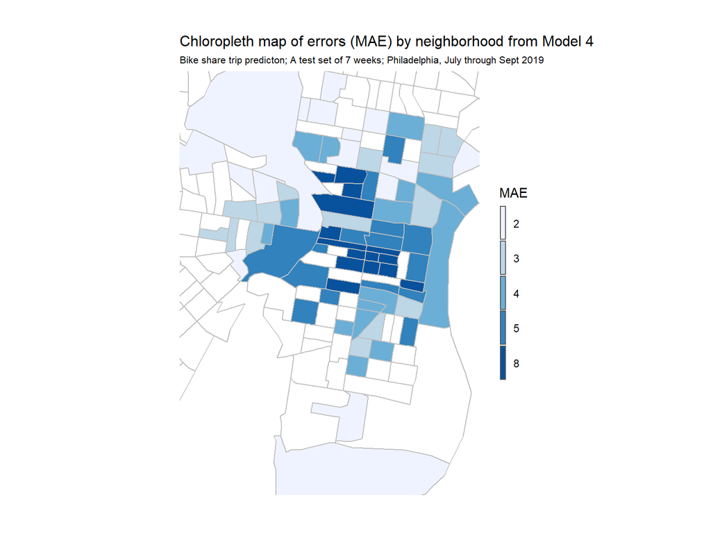

```r
# Chloropleth map of errors (MAE) by neighborhood from Model 4
filter(week_predictions, Regression == "DTime_Space_FE_timeLags") %>%
  unnest() %>%
  left_join(., PhillyTracts, by = c("Origin.Tract" = "GEOID")) %>%
  st_sf() %>%
  dplyr::select(Origin.Tract, Absolute_Error, geometry) %>%
  gather(Variable, Value, -Origin.Tract, -geometry) %>%
  group_by(Variable, Origin.Tract) %>%
  na.omit() %>%
  summarize(MAE = mean(Value)) %>%
  ggplot() +
  geom_sf(aes(fill = q5(MAE))) +
  scale_fill_manual(values = palette5,
                    labels = c("2", "3", "4", "5", "8"),
                    name = "MAE") +
  ylim(min(Philly_dat_Census$from_latitude), max(Philly_dat_Census$from_latitude))+
  xlim(min(Philly_dat_Census$from_longitude), max(Philly_dat_Census$from_longitude))+
  labs(title="Chloropleth map of errors (MAE) by neighborhood from Model 4",
       subtitle = "Bike share trip predicton; A test set of 7 weeks; Philadelphia, July through Sept 2019") +
  geom_sf(data=PhillyTracts,color = "grey", fill = "transparent") +
  mapTheme
```

Next, a time/space MAE series is mapped for just the Monday of the 35th week. The interpretation of this map is fascinating. Despite relatively few trips and also errors occurring during the overnight hours, errors are distributed across the Central City area - perhaps because there are fewer systematic patterns in how ride share is taken so early on a Monday morning. Between 12pm and 5pm, errors are still prevalent and distributed widely but the errors seem to decline as the number of trips decrease. Besides, errors appear more mixed for both morning and evening hours.

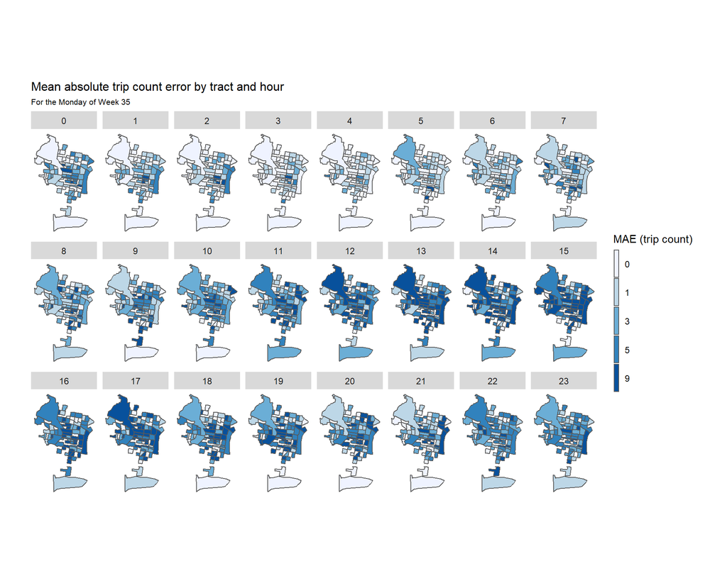

```r
# Mean absolute trip count error by tract and hour
filter(week_predictions, Regression == "DTime_Space_FE_timeLags") %>%
  unnest() %>%
  left_join(., PhillyTracts, by = c("Origin.Tract" = "GEOID")) %>%
  st_sf() %>%
  dplyr::select(Origin.Tract, Absolute_Error, geometry, interval60) %>%
  gather(Variable, Value, -interval60, -Origin.Tract, -geometry) %>%
  filter(wday(interval60, label = TRUE) == "Mon" & week(interval60) == 35) %>%
  group_by(hour = hour(interval60), Origin.Tract) %>%
  summarize(MAE = mean(Value)) %>%
  ggplot() +
  geom_sf(aes(fill = q5(MAE))) +
  facet_wrap(~hour, ncol = 8) +
  scale_fill_manual(values = palette5,
                    labels = c("0", "1", "3", "5", "9"),
                    name = "MAE (trip count)") +
  labs(title="Mean absolute trip count error by tract and hour",
       subtitle = "For the Monday of Week 35") +
  mapTheme
```

#### 5.2.3 Validate test set by Socio-economic Factors

**Mean commute time**: the model predicts pretty well where people spend less commute time.

**Percent of population taking public transit**: the model predicts pretty well where there is higher percent of population taking public transit.

**Median age**: the model predicts pretty well where people with median age around 20 and median age above 50.

**Percent of White population**: the model predicts well where there is fewer percent of White population.

**Median household income**: the model predicts well where there is lower median household income (less than 30,000).

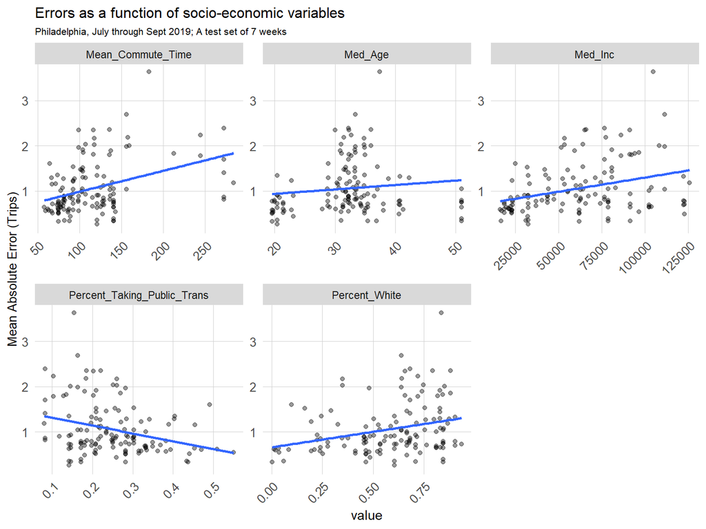

```r
#Error as a function of socio-economic factors
week_predictions %>%
  mutate(interval60 = map(data, pull, interval60),
         start_station= map(data, pull, start_station),
         from_latitude = map(data, pull, from_latitude),
         from_longitude = map(data, pull, from_longitude),
         dotw = map(data, pull, dotw),
         Percent_Taking_Public_Trans = map(data, pull, Percent_Taking_Public_Trans),
         Med_Inc = map(data, pull, Med_Inc),
         Percent_White = map(data, pull, Percent_White),
         Med_Age=map(data,pull,Med_Age),
         Mean_Commute_Time = map(data,pull, Mean_Commute_Time)) %>%
  dplyr::select(interval60, start_station, from_longitude,
                from_latitude, Observed, Prediction, Regression,
                dotw, Percent_Taking_Public_Trans, Med_Inc, Percent_White, Med_Age,Mean_Commute_Time) %>%
  unnest() %>%
  filter(Regression == "ETime_Space_FE_timeLags_holidayLags")%>%
  mutate(weekend = ifelse(dotw %in% c("Sun", "Sat"), "Weekend", "Weekday"),
         time_of_day = case_when(hour(interval60) < 7 | hour(interval60) > 18 ~ "Overnight",
                                 hour(interval60) >= 7 & hour(interval60) < 10 ~ "AM Rush",
                                 hour(interval60) >= 10 & hour(interval60) < 15 ~ "Mid-Day",
                                 hour(interval60) >= 15 & hour(interval60) <= 18 ~ "PM Rush")) %>%
  filter(time_of_day == "AM Rush") %>%
  group_by(start_station, Percent_Taking_Public_Trans, Med_Inc, Percent_White, Med_Age,Mean_Commute_Time) %>%
  summarize(MAE = mean(abs(Observed-Prediction), na.rm = TRUE))%>%
  gather(-start_station, -MAE, key = "variable", value = "value")%>%
  ggplot(.)+
  #geom_sf(data = phillyCensus, color = "grey", fill = "transparent")+
  geom_point(aes(x = value, y = MAE), alpha = 0.4)+
  geom_smooth(aes(x = value, y = MAE), method = "lm", se= FALSE)+
  facet_wrap(~variable, scales = "free")+
  labs(title="Errors as a function of socio-economic variables",
       subtitle = "Philadelphia, July through Sept 2019; A test set of 7 weeks",
       y="Mean Absolute Error (Trips)")+
  plotTheme
```

## 6. Conclusion

In conclusion, the model does not predict well for where and when more trips are likely to occur, as there are higher errors taking place in those context, for example, the rush hours in Central City, which may result in lack of bycicles in high demand areas and time periods. Moreover, the key takeaway is that the model underpredicts the bike share demand during rush hours in Central City in weekdays. Therefore, one piece of advice is, Indego should supply more bike share during those time slots in Central City, and people should be prepared to schedule well if they need to use bike share service at those times in Central City.

Furthermore, the existences of errors in the spatial pattern indicates that the model still has some issues with spatial autocorrelation. Perhaps I can add spatial lags in the model to better illustrate the spatial structure of the data. In addition, when I set errors as a function of socio-economic variables, it shows that the model doesn’t predict well in certain groups, which may be improved by adding new features like the gender of the users, the travel time of the trips, and so on

Finally, the positive side of the model is that it’s good at predicting when and where trips are less frequent, such as non-rush hour during weekdays and in the areas aways from Central City, which could be refered by Indego when they would like to improve their services.